# COMPSCIX 415.2 Homework 2

## 3.3.1 Exercises

*1. What’s gone wrong with this code? Why are the points not blue?*

The points are not blue because the “color = blue” is within the aesthetic argument brackets. To make the points blue, the aes brackets must be closed and the “color” argument must be within the geom_point brackets, but after the aes brackets.

*2. Which variables in mpg are categorical? Which variables are continuous? (Hint: type ?mpg to read the documentation for the dataset). How can you see this information when you run mpg?*

The categorical variables are: model name, transmission type, driving type, type of car. The continuous variables are: displacement, year, number of cylinders, city mpg, highway mpg.

*3. Map a continuous variable to color, size, and shape. How do these aesthetics behave differently for categorical vs. continuous variables?*

When you map color to a continous variable, it creates a gradient. When you map size to a continous variable, it creates a gradient of size. Continuos variables cannot be used with shape.

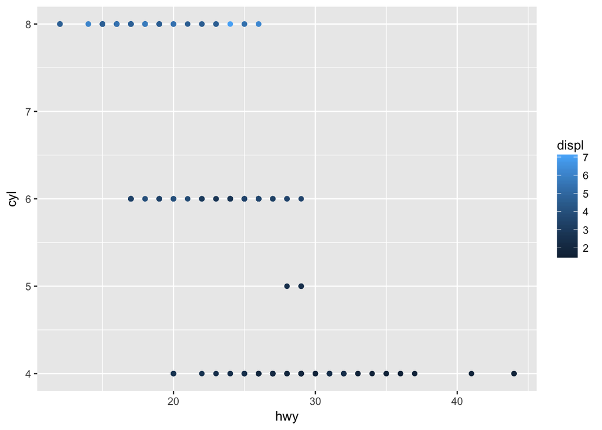

```r
data("mpg")

ggplot(data = mpg) +
  geom_point(mapping = aes(x = hwy, y = cyl, color=displ))
```

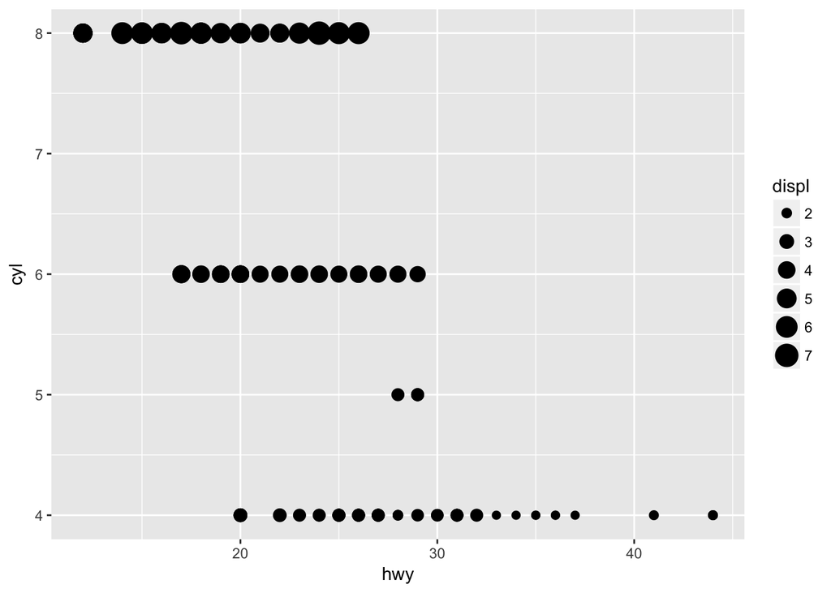

```r
ggplot(data = mpg) +
  geom_point(mapping = aes(x = hwy, y = cyl, size=displ))
```

*4. What happens if you map the same variable to multiple aesthetics?*

If you map the same variable to multiple aesthetics, the graph will build with both aesthetics.

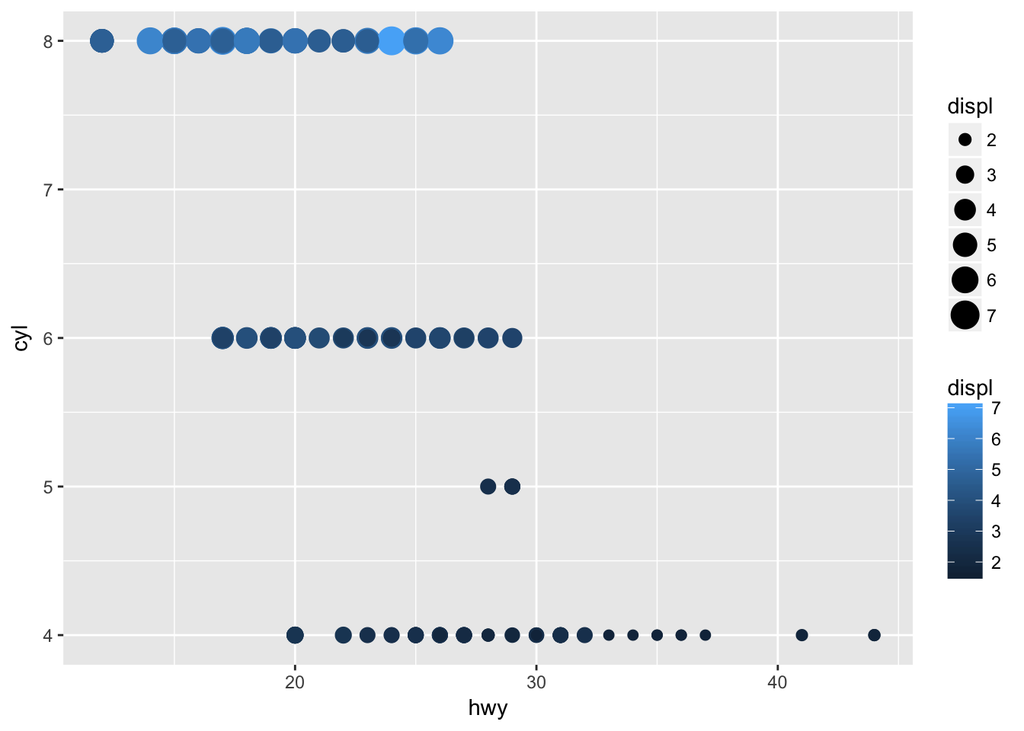

```r
data("mpg")

ggplot(data = mpg) +
  geom_point(mapping = aes(x = hwy, y = cyl, color=displ,size=displ))
```

*5. What does the stroke aesthetic do? What shapes does it work with? (Hint: use ?geom_point)*

Stroke controls the boarder width of select shapes (# 21-25).

*6. What happens if you map an aesthetic to something other than a variable name, like aes(colour = displ < 5)?*

If used with a condition, the aesthetic will create two types (e.g. two sizes) that map to the condition being true and another for the condition being false.

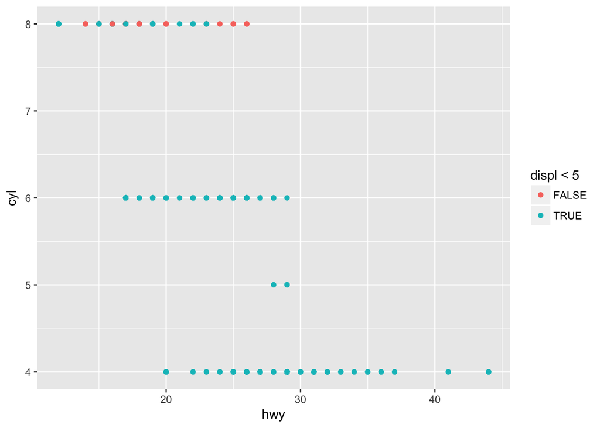

```r
data("mpg")

ggplot(data = mpg) +
  geom_point(mapping = aes(x = hwy, y = cyl, color=displ < 5))
```

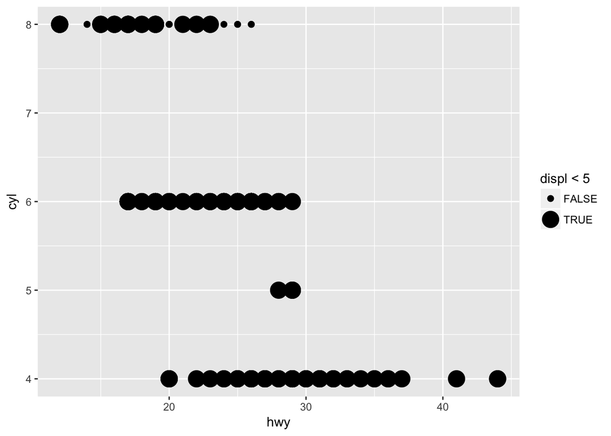

```r
ggplot(data = mpg) +
  geom_point(mapping = aes(x = hwy, y = cyl, size=displ < 5))
```